# Linear models with factors

Read the chapter 14-16

Predictors that are qualitative in nature, for example, eye color, are sometimes described as categorical or called factors. We wish to incorporate these predictors into the regression analysis.

# 1 A two level factor

The dataset `sexab` for this example come from a study of the effects of childhood sexual abuse on adult females. See the data description in R.

```r
library(faraway)
data(sexab,package="faraway")
sexab[c(1:5,51:55),]
```

```
##         cpa     ptsd       csa
## 1   2.04786  9.71365    Abused
## 2   0.83895  6.16933    Abused
## 3  -0.24139 15.15926    Abused
## 4  -1.11461 11.31277    Abused
## 5   2.01468  9.95384    Abused
## 51  2.65339  6.33934 NotAbused
## 52  3.75443  7.29694 NotAbused
## 53  1.51153 -3.34921 NotAbused
## 54  1.75392  4.46763 NotAbused
## 55 -0.45860  4.01823 NotAbused
```

```r
by(sexab,sexab$csa,summary)
```

```
## sexab$csa: Abused
##       cpa              ptsd               csa
##  Min.   :-1.115   Min.   : 5.985   Abused   :45
##  1st Qu.: 1.415   1st Qu.: 9.374   NotAbused: 0
##  Median : 2.627   Median :11.313
##  Mean   : 3.075   Mean   :11.941
##  3rd Qu.: 4.317   3rd Qu.:14.901
##  Max.   : 8.647   Max.   :18.993
## --------------------------------------------------------
## sexab$csa: NotAbused
##       cpa               ptsd               csa
##  Min.   :-3.1204   Min.   :-3.349   Abused   : 0
##  1st Qu.:-0.2299   1st Qu.: 3.544   NotAbused:31
##  Median : 1.3216   Median : 5.794
##  Mean   : 1.3088   Mean   : 4.696
##  3rd Qu.: 2.8309   3rd Qu.: 6.838
##  Max.   : 5.0497   Max.   :10.914
```

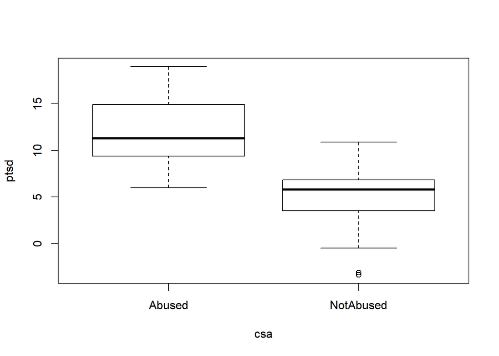

```r
plot(ptsd ~ csa, sexab)
```

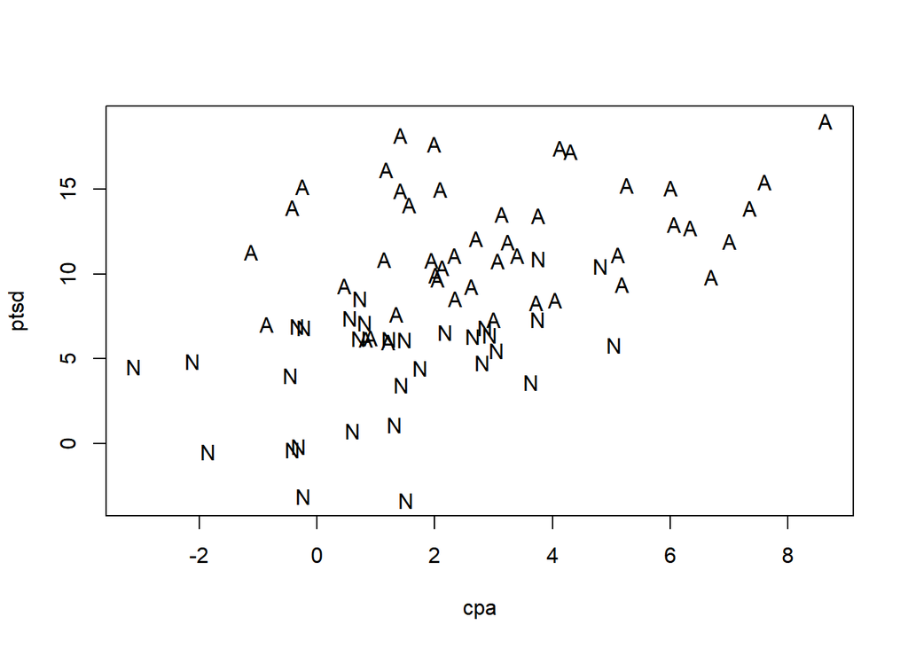

```r
plot(ptsd ~ cpa, pch=as.character(csa), sexab)
```

We see a clear difference in PTSD levels in accordance with CSA. Let us test the differnece by T-test.

```r
t.test(ptsd ~ csa, sexab, var.equal=TRUE)
```

```
##
##  Two Sample t-test
##
## data:  ptsd by csa
## t = 8.9387, df = 74, p-value = 2.172e-13
## alternative hypothesis: true difference in means is not equal to 0
## 95 percent confidence interval:
##  5.630165 8.860273
## sample estimates:
##    mean in group Abused mean in group NotAbused
##               11.941093                4.695874
```

We find the difference is significant.

Our strategy is to incorporate qualitative predictors within the linear regression framework. We can do this using a dummy variable. For a categorical predictor (or factor) with two levels, we define a dummy variable as

$$d = I(CSA ~ is ~ reported)$$

```r
d <- ifelse(sexab$csa == "Abused",1,0)
lmod <- lm(ptsd ~ d, sexab)
sumary(lmod)
```

```
##             Estimate Std. Error t value  Pr(>|t|)
## (Intercept)  4.69587    0.62370  7.5290 1.003e-10
## d            7.24522    0.81055  8.9387 2.172e-13
##
## n = 76, p = 2, Residual SE = 3.47264, R-Squared = 0.52
```

```r
model.matrix(lmod)
```

```
##    (Intercept) d
## 1            1 1
## 2            1 1
## 3            1 1
## 4            1 1
## 5            1 1
## 6            1 1
## 7            1 1
## 8            1 1
## 9            1 1
## 10           1 1
## 11           1 1
## 12           1 1
## 13           1 1
## 14           1 1
```

[output cut: 64 more lines]

The estiamted model is

$$\widehat{PTSD} = 4.70 + 7.25*d$$

What does the estimated coefficients mean? The intercept (4.70) is the mean PTSD for non-abused group ($d=0$). The slope (7.25) means the difference on the mean PTSD between groups (abused vs non-abused). And, the above result tells us that the slope is significant, which means that there is a significant difference betweeb groups. This result is consistent with that of T-test. Moreover, we can see that the observed test statistic (8.9387) coincide.

Note] We need the equal variances assumption for our regression model to be valid. And, observe that we performed the T-test under the equal variances assumption as well.

In fact, we don’t need to introduce the dummy variable in this example since in many cases it is automatically done by R.

```r
lmod <- lm(ptsd ~ csa, sexab)
sumary(lmod)
```

```
##              Estimate Std. Error t value  Pr(>|t|)
## (Intercept)  11.94109    0.51767 23.0670 < 2.2e-16
## csaNotAbused -7.24522    0.81055 -8.9387 2.172e-13
##
## n = 76, p = 2, Residual SE = 3.47264, R-Squared = 0.52
```

```r
class(sexab$csa)
```

```
## [1] "factor"
```

Note here that the sign of the estimated slope is reversed. This is because, in R, the reference level (0 level) is alphabetically determined. If one want to change it manullay, do as

```r
sexab$csa <- relevel(sexab$csa, ref="NotAbused")
lmod <- lm(ptsd ~ csa, sexab)
sumary(lmod)
```

```
##             Estimate Std. Error t value  Pr(>|t|)
## (Intercept)  4.69587    0.62370  7.5290 1.003e-10
## csaAbused    7.24522    0.81055  8.9387 2.172e-13
##
## n = 76, p = 2, Residual SE = 3.47264, R-Squared = 0.52
```

Note that they give essentially the same information.

# 2 Factors and Quantitative Predictors

Now we add CPA (quantitative) variable into the model. Therefore, we now have two predictors. This may give some adjustment into the model since CPA($x$) may also affect PTSD($y$) as well as CSA($d$). We are going to try two models

1. Regression lines for each group with the same slope: $y=\beta_0 + \beta_1 x + \beta_2 d + \epsilon$
2. Regression lines for each group with the different slopes: $y=\beta_0 + \beta_1 x + \beta_2 d + \beta_3 xd + \epsilon$

We call $\beta_3$ a interaction effect since this produces a different slopes for different levels of $d$.

```r
lmod4 <- lm(ptsd ~ cpa+csa+cpa:csa,sexab)
#lmod4 <- lm(ptsd ~ cpa*csa,sexab)   #   the same as above
sumary(lmod4)
```

```
##               Estimate Std. Error t value  Pr(>|t|)
## (Intercept)    3.69591    0.71066  5.2007 1.790e-06
## cpa            0.76400    0.30383  2.5146   0.01415
## csaAbused      6.86121    1.07475  6.3840 1.479e-08
## cpa:csaAbused -0.31396    0.36848 -0.8520   0.39702
##
## n = 76, p = 4, Residual SE = 3.27931, R-Squared = 0.58
```

```r
head(model.matrix(lmod4))
```

```
##   (Intercept)      cpa csaAbused cpa:csaAbused
## 1           1  2.04786         1       2.04786
## 2           1  0.83895         1       0.83895
## 3           1 -0.24139         1      -0.24139
## 4           1 -1.11461         1      -1.11461
## 5           1  2.01468         1       2.01468
## 6           1  6.71131         1       6.71131
```

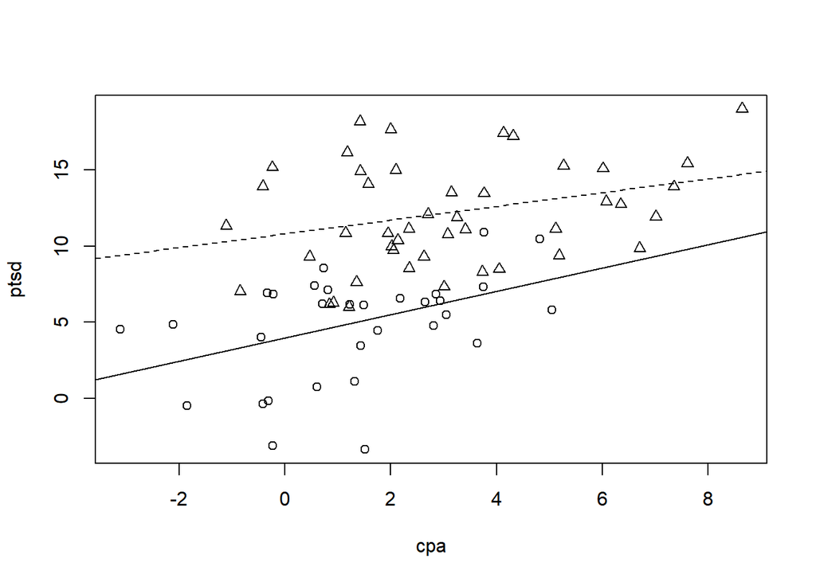

```r
plot(ptsd ~ cpa, sexab, pch=as.numeric(csa))
abline(3.96, 0.764)
abline(3.96+6.86, 0.764-0.314,lty=2)
```

The model can be simplified because the interaction term is not significant. We reduce to this model:

```r
lmod3 <- lm(ptsd ~ cpa+csa,sexab)
sumary(lmod3)
```

```
##             Estimate Std. Error t value  Pr(>|t|)
## (Intercept)  3.97528    0.62931  6.3169 1.871e-08
## cpa          0.55055    0.17158  3.2086  0.001982
## csaAbused    6.27275    0.82191  7.6320 6.907e-11
##
## n = 76, p = 3, Residual SE = 3.27314, R-Squared = 0.58
```

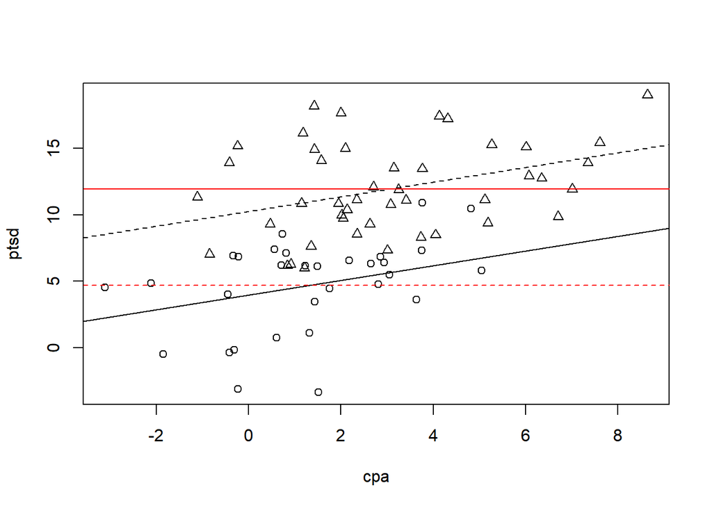

```r
plot(ptsd ~ cpa, sexab, pch=as.numeric(csa))
abline(3.98, 0.551)
abline(3.98+6.27, 0.551, lty=2)
ma = mean(sexab$ptsd[sexab$csa == "Abused"])
mna = mean(sexab$ptsd[sexab$csa != "Abused"])
abline(h=ma,col=2)
abline(h=mna,col=2, lty=2)
```

Now the two linear lines are parallel. Note that the slope of both lines is 0.551, but the “Abused” line is 6.273 higher than the “NonAbused.” From the one predictor model earlier, the unadjusted estimated effect of childhood sexual abuse is 7.245. So after adjusting for the effect of childhood physical abuse, our estimate of the effect of childhood sexual abuse on PTSD is mildly reduced. This can be viewed in the above plot (red lines).

A homeowner in England recorded his weekly natural gas consumption, in thousands of cubic feet, during two winter heating seasons. For the second season, cavity wall insulation had been installed. The homeowner also recorded the average weekly temperature in degrees Celsius because this would also affect gas consumption. The data may be found in the MASS package.

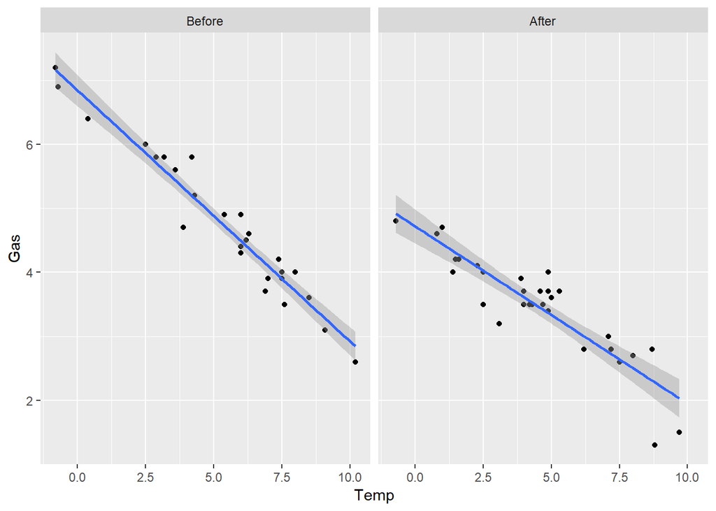

```r
data(whiteside,package="MASS")
require(ggplot2)
ggplot(aes(x=Temp,y=Gas),data=whiteside)+geom_point()+facet_grid(~ Insul)+geom_smooth(method="lm")
```

We can see that less gas is used after the insulation is installed but the difference varies by temperature.

# 3 Factors With More Than Two Levels

Suppose we have a factor with 3 levels (A,B,C). Then, we need 2 dummy variables to include the factor into the model properly.

$$d_1=I(B),~d_2 = I(C).$$

If the level is A, $d_1=0,d_2=0$. If the level is B, $d_1=1, d_2=0$. If it is C, $d_1=0,d_2=1$. Of course, different kinds of definitions are possible. Generally, we need $f-1$ dummy variabels with a $f$ levels factor variable.

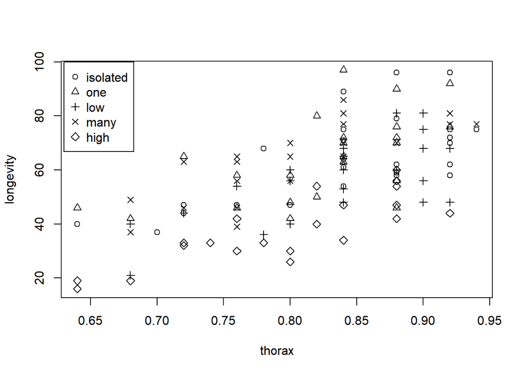

```r
data(fruitfly,package="faraway")
plot(longevity ~ thorax, fruitfly, pch=unclass(activity))
legend(0.63,100,levels(fruitfly$activity),pch=1:5)
```

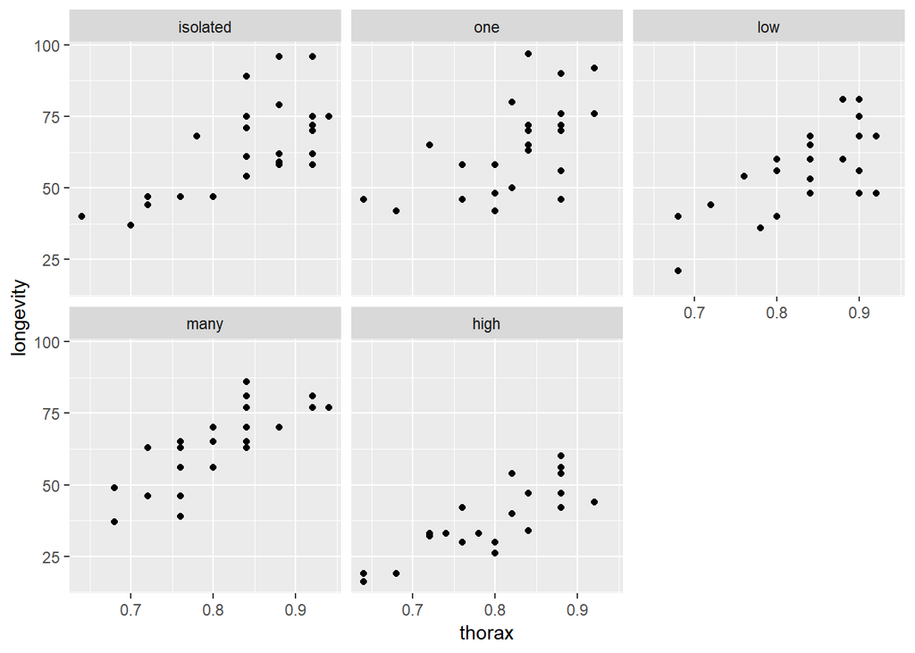

```r
require(ggplot2)
ggplot(aes(x=thorax,y=longevity),data=fruitfly) + geom_point() + facet_wrap( ~ activity)
```

```r
lmod <- lm(longevity ~ thorax*activity, fruitfly)
sumary(lmod)
```

```
##                      Estimate Std. Error t value  Pr(>|t|)
## (Intercept)         -50.24197   21.80118 -2.3046    0.0230
## thorax              136.12676   25.95172  5.2454 7.275e-07
## activityone           6.51716   33.87083  0.1924    0.8478
## activitylow          -7.75013   33.96901 -0.2282    0.8199
## activitymany         -1.13943   32.52975 -0.0350    0.9721
## activityhigh        -11.03803   31.28660 -0.3528    0.7249
## thorax:activityone   -4.67713   40.65175 -0.1151    0.9086
## thorax:activitylow    0.87431   40.42531  0.0216    0.9828
## thorax:activitymany   6.54779   39.36002  0.1664    0.8682
## thorax:activityhigh -11.12676   38.11997 -0.2919    0.7709
##
## n = 124, p = 10, Residual SE = 10.71275, R-Squared = 0.65
```

Interpretation?

Observe the model matrix (design matrix)

```r
model.matrix( lm(longevity ~ thorax+activity, fruitfly))
```

```
##     (Intercept) thorax activityone activitylow activitymany activityhigh
## 1             1   0.68           0           0            1            0
## 2             1   0.68           0           0            1            0
## 3             1   0.72           0           0            1            0
## 4             1   0.72           0           0            1            0
## 5             1   0.76           0           0            1            0
## 6             1   0.76           0           0            1            0
## 7             1   0.76           0           0            1            0
## 8             1   0.76           0           0            1            0
## 9             1   0.76           0           0            1            0
## 10            1   0.80           0           0            1            0
## 11            1   0.80           0           0            1            0
## 12            1   0.80           0           0            1            0
## 13            1   0.84           0           0            1            0
## 14            1   0.84           0           0            1            0
```

[output cut: 115 more lines]

# 4 ALternative codings

Consider a four-level factor that will be coded using three dummy variables. This contrast matrix describes the coding, where the columns represent the dummy variables and the rows represent the levels:

Let’s see by 4 levels example.

```r
contr.treatment(4)  # Treatment coding (default in R)
```

```
##   2 3 4
## 1 0 0 0
## 2 1 0 0
## 3 0 1 0
## 4 0 0 1
```

```r
contr.helmert(4)    # Helmert coding
```

```
##   [,1] [,2] [,3]
## 1   -1   -1   -1
## 2    1   -1   -1
## 3    0    2   -1
## 4    0    0    3
```

```r
contr.sum(4)        # sum coding (intercept becomes the mean response)
```

```
##   [,1] [,2] [,3]
## 1    1    0    0
## 2    0    1    0
## 3    0    0    1
## 4   -1   -1   -1
```

```r
contrasts(sexab$csa) <- contr.sum(2)
sumary(lm(ptsd ~ csa, sexab))
```

```
##             Estimate Std. Error t value  Pr(>|t|)
## (Intercept)  8.31848    0.40527 20.5256 < 2.2e-16
## csa1        -3.62261    0.40527 -8.9387 2.172e-13
##
## n = 76, p = 2, Residual SE = 3.47264, R-Squared = 0.52
```

The mean response is 8.32. And, the effect is $8.32 \pm 3.62$.

# 5 Exercise

1. # 14.1